# Demo: Network Inference

Network inference based on de-correlated score test

## Generate Spike Train Data

### Generate connectivity matrix

I created functions that generate both the connectivity matrix (3-dimensional (M,p,p) array) and the background rate (2-dimensional (M,p) array). I save those functions in **genSetting.py**

```python
import numpy as np
from genSetting import genCircleStarThreeNetworks
print_max  = lambda x : np.round( np.max( abs(np.real(x) ) ) , 2)

U, Beta= genCircleStarThreeNetworks(m=10,star_coef =0.6, circle_coef = 0.6, U_coef=0.1)
M = U.shape[0]
'max eigen value of Connectivity Matrix:', [print_max( Beta[m]) for m in range(M)]
```

```
('max eigen value of Connectivity Matrix:', [0.6, 0.6, 0.6])
```

### Visualize true network structures

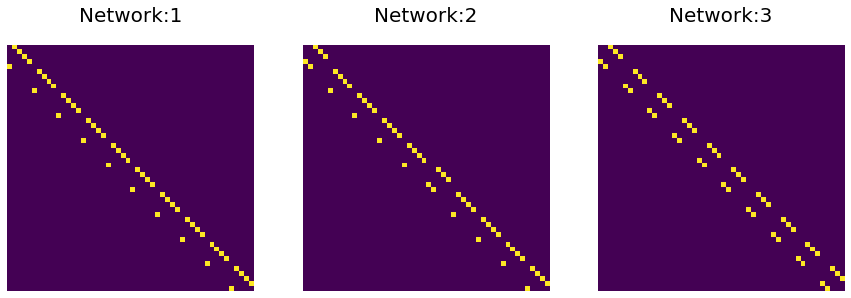

```python
import matplotlib.pyplot as plt

fig, axs = plt.subplots(1, 3,figsize=(15,45))
for m in range(M):
    axs[m].axis('off')
    axs[m].matshow(Beta[m]!=0)
    axs[m].set_title('Network:'+ str(m+1) ,fontsize=20)
```

### Generate spike train data

Given the connectivity matrix and the background intensity rate as inputs, I generate spike train data from p processes under M experiment. The function **simu_net** is saved in **simu_net.py**

```python
from simu_net import simu_net
T =  [1000,1000,1000] #
rho, rate, lag = 2, 1, 1
M = Beta.shape[0]
p = Beta.shape[1]

np.random.seed(123)
DATA = simu_net( T, # length of each experiment, array of length M
                M, # no. experiments
                p, # no. processes
                Beta, U, # connectivity matrix and the background intensity rate
                rho , rate, lag # parameter used for transition kernel
               )
Spike = DATA['Spike'] # output Spike, the spike train data, is a dictionary of length M with its value a p x p matrix
Phi = DATA['Phi'] # output Phi, the transition matrix, is a dictionary of length M with its value a p x p matrix
```

## Network Inference

The key function, **net_inf**, conducting inference for each of the multi-experiment networks are saved in **net_inf.py**. The function provides p-values in testing each edge of each networks, using the de-correlated score test. **net_inf** requires input of the spike train data, saved as dictionary where each item is a data matrix at each experiment.

```python
from net_inf import net_inf
```

### Inference with default design matrix (exp decay) and default model coefficeint (by lasso)

In this part, we call **net_inf** to make inference over the edges of each network. Without giving the design matrix and any estimated connectivity coefficients, the function create default design matrix using expoenential decay kernel, and estimate the connectivity coefficeints separately for each network using lasso.

```python
V,PVAL, LCI, UCI = net_inf( Y= Spike   # outcome, dict, for all experiments
                            #X = None , # design matrix, dict, default None, created using exponential decay
                            #COEF=None , # 3D-array estimated coefficents, (M,p,p+1),if not given, est. using lasso
                            #msg = False # show progress of iterations
                          )
```

```
network 1 ~type 1 error:  0.044489795918367346 power 1.0
network 2 ~type 1 error:  0.04775510204081632 power 1.0
network 3 ~type 1 error:  0.04326530612244898 power 1.0
```

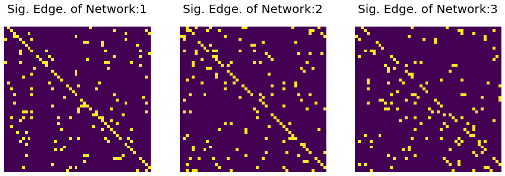

```python
for m in range(M):
    D1 = PVAL[m] < 0.05
    D2 = Beta[m] == 0
    D3 = Beta[m]!=0
    print('network', m+1, '~type 1 error: ', np.sum( D1 * D2 )/ np.sum( D2), \
          'power' , np.sum( D1 * D3 )/ np.sum( D3) )


# plot estimated connectivity matrix
fig, axs = plt.subplots(1, 3,figsize=(15,45))
for m in range( M):
    axs[m].axis('off')
    axs[m].matshow(PVAL[m] <0.05)
    axs[m].set_title('Sig. Edge. of Network:'+ str(m+1) ,fontsize=20)
```

```python
from igraph import *
Edges = (PVAL < 0.05)*1.0
```

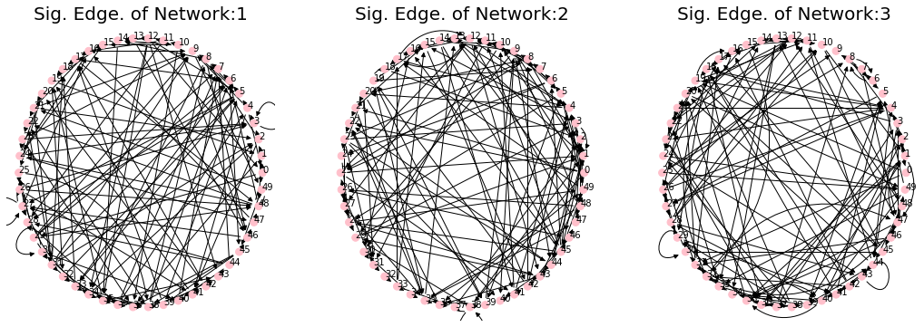

```python
fig, axs = plt.subplots(1, 3,figsize=(18, 6))

for m in range(M):
    axs[m].axis('off')

    g = Graph.Adjacency(Edges[m])
    if m ==0:
        layout = g.layout_circle( )
    plot(g,  layout = layout ,
             vertex_color='pink',
             vertex_label = np.arange(Edges[m].shape[0]),
             vertex_size = 8,
             target= axs[m] )

    axs[m].set_title('Sig. Edge. of Network:'+ str(m+1) ,fontsize=20)
```

### With pre-specificed model coefficeints

In this part, we call **net_inf** to make inference over the edges of each network using the estimated connectivity coefficeints (e.g. via separate or joint estimation).

#### with true model coefficients

```python
COEF =  np.array( [ np.column_stack( [ U[m] , Beta[m]] )  for m in range(M) ] )
#COEF0 = COEF[0].reshape( (1, p, p+1))
V,PVAL, LCI, UCI = net_inf( Y= Spike , COEF = COEF )
```

```
network 1 type 1 error:  0.044489795918367346 power 1.0
network 2 type 1 error:  0.044897959183673466 power 1.0
network 3 type 1 error:  0.046122448979591835 power 1.0
```

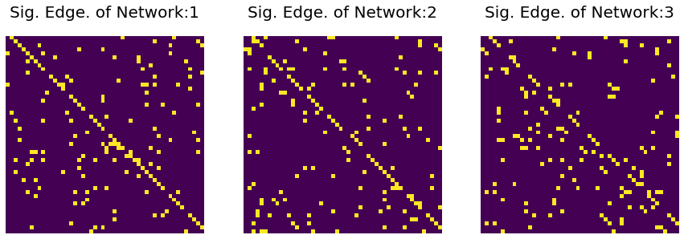

```python
for m in range(M):
    D1 = PVAL[m] < 0.05
    D2 = Beta[m] == 0
    D3 = Beta[m]!=0
    print('network', m+1, '~type 1 error: ', np.sum( D1 * D2 )/ np.sum( D2), 'power' , np.sum( D1 * D3 )/ np.sum( D3) )


# plot estimated connectivity matrix
fig, axs = plt.subplots(1, 3,figsize=(15,45))
for m in range( M):
    axs[m].axis('off')
    axs[m].matshow(PVAL[m] <0.05)
    axs[m].set_title('Sig. Edge. of Network:'+ str(m+1) ,fontsize=20)
```

```python
#### with estimated model coefficients
```

```python
from net_est_auto import net_est
EST_ALL = net_est( Y=Spike)
BETA_EST = EST_ALL['BETA_EST']
U_EST = EST_ALL['U_EST']
```

```python
COEF_EST =  np.array( [ np.column_stack( [ U_EST[m] , BETA_EST[m]] )  for m in range(M) ] )
#COEF0 = COEF[0].reshape( (1, p, p+1))
V,PVAL, LCI, UCI = net_inf( Y= Spike , COEF = COEF_EST )
```

```
network 1 type 1 error:  0.044489795918367346 power 1.0
network 2 type 1 error:  0.04775510204081632 power 1.0
network 3 type 1 error:  0.04326530612244898 power 1.0
```

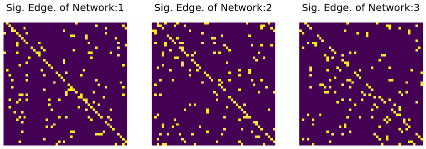

```python
for m in range(M):
    D1 = PVAL[m] < 0.05
    D2 = Beta[m] == 0
    D3 = Beta[m]!=0
    print('network', m+1, '~type 1 error: ', np.sum( D1 * D2 )/ np.sum( D2), 'power' , np.sum( D1 * D3 )/ np.sum( D3) )


# plot estimated connectivity matrix
fig, axs = plt.subplots(1, 3,figsize=(15,45))
for m in range( M):
    axs[m].axis('off')
    axs[m].matshow(PVAL[m] <0.05)
    axs[m].set_title('Sig. Edge. of Network:'+ str(m+1) ,fontsize=20)
```